# RforDataScienceCh1

## 4. Make a scatterplot of hwy vs cyl

First, hwy is “highway miles per gallon”, a measure of fuel economy, and cyl is a measure of the number of cylinders an engine has. We can use the context to hypothesize that there is a negative relationship between the number of cylinders and the highway miles per gallon.

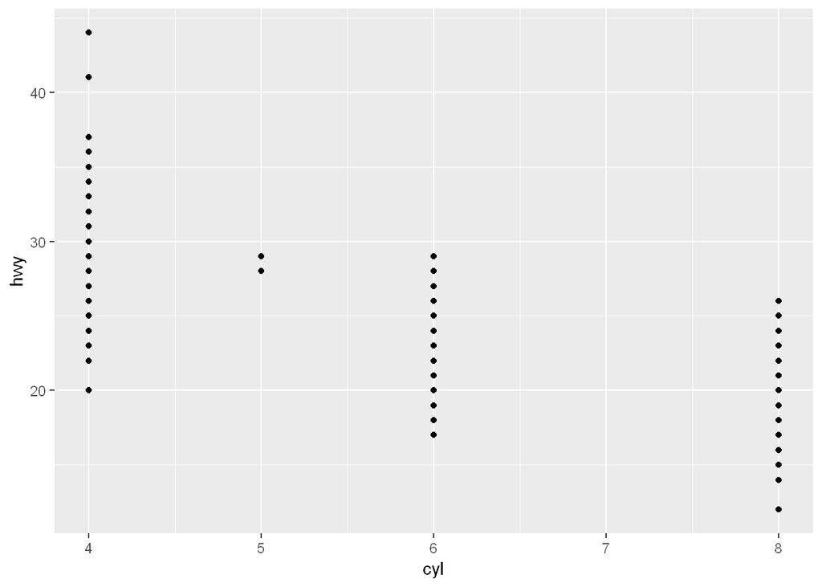

```r
ggplot(data = mpg) +
  geom_point(aes(x = cyl, y = hwy))
```

## 5. What happens if you make scatterplot of class versus drv? Why is the plot not useful?

class is the type of car, and drv is the type of drivetrain. class and drv are both of type chr.

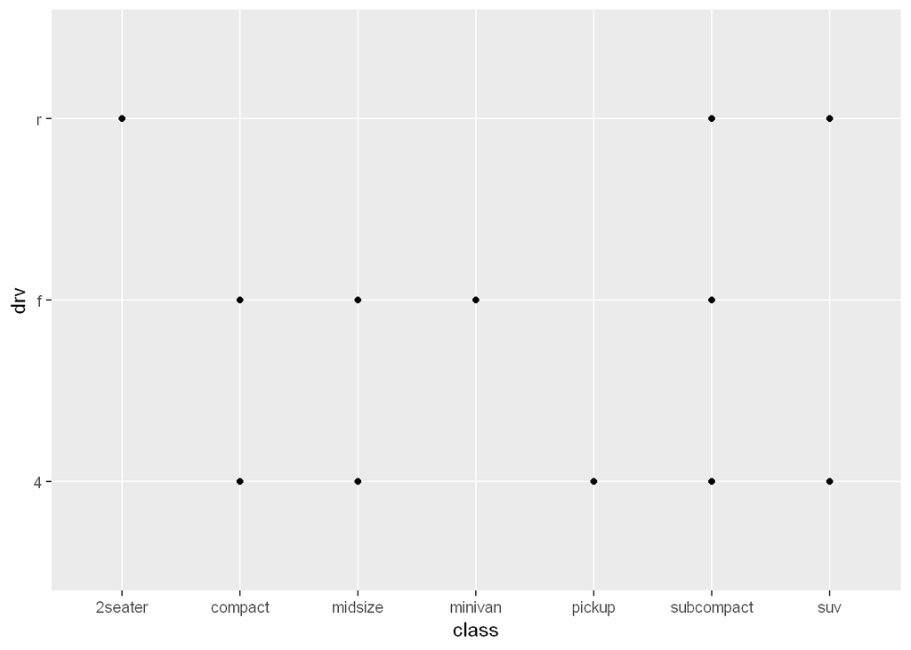

```r
ggplot(data = mpg) +
  geom_point(aes(x = class, y = drv))
```

There is no clear order to either variable, so we cannot surmise a meaningful relationship between the two variables. It does not mean anything to say “as class increases, drivetrain decreases.” Therefore, a scatterplot does not convey useful information in that regard. However it still allows us to quickly see which classes of cars tend to offer rear, f, or 4 drive trains, so I don’t agree that it’s not useful.

## Unasked questions : messing around with lm

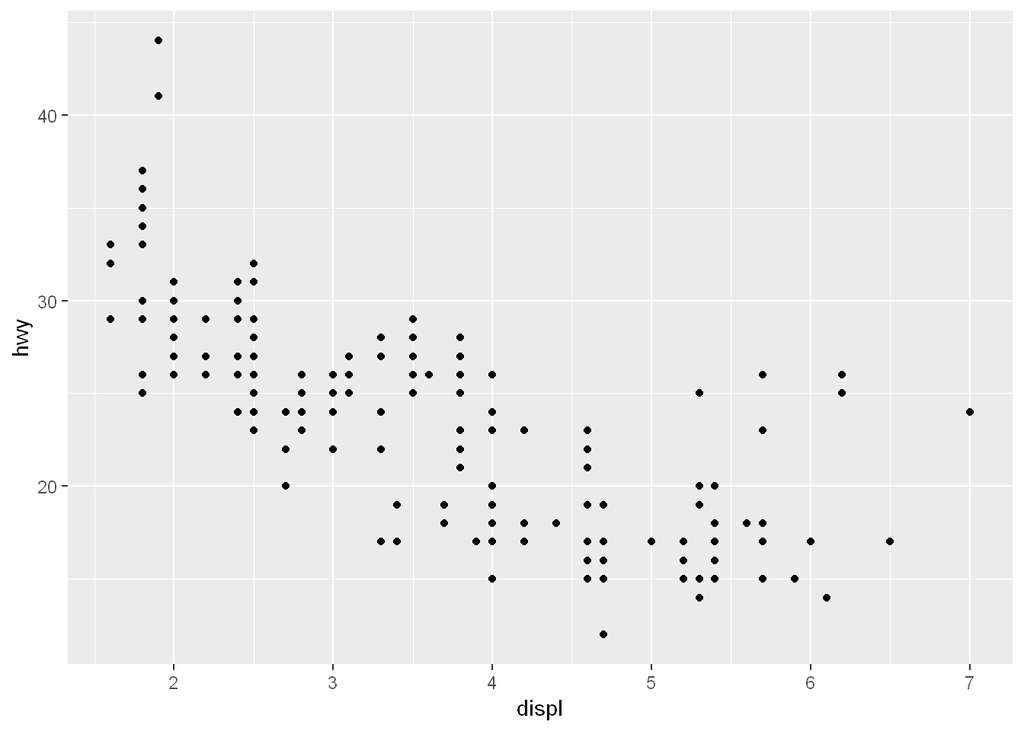

```r
ggplot(data = mpg) +
  geom_point(aes(x = displ, y = hwy))
```

```r
model1 <- lm(hwy ~ displ, mpg)
summary(model1)
```

```
##
## Call:
## lm(formula = hwy ~ displ, data = mpg)
##
## Residuals:
##     Min      1Q  Median      3Q     Max
## -7.1039 -2.1646 -0.2242  2.0589 15.0105
##
## Coefficients:
##             Estimate Std. Error t value Pr(>|t|)
## (Intercept)  35.6977     0.7204   49.55   <2e-16 ***
## displ        -3.5306     0.1945  -18.15   <2e-16 ***
## ---
## Signif. codes:  0 '***' 0.001 '**' 0.01 '*' 0.05 '.' 0.1 ' ' 1
##
## Residual standard error: 3.836 on 232 degrees of freedom
## Multiple R-squared:  0.5868, Adjusted R-squared:  0.585
## F-statistic: 329.5 on 1 and 232 DF,  p-value: < 2.2e-16
```

Let’s color by car type.

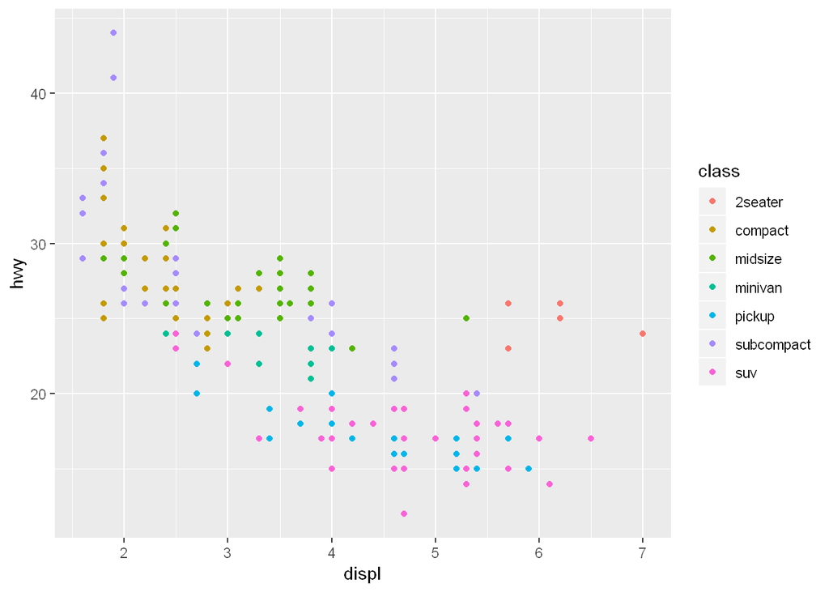

```r
ggplot( data = mpg ) +
  geom_point(aes(x = displ, y = hwy, color = class))
```

Let’s filter out 2 seaters, subcompacts, and hwy >= 40, because these seem to affect the linearity of the relationship, and in some cases seem to be outright outliers.

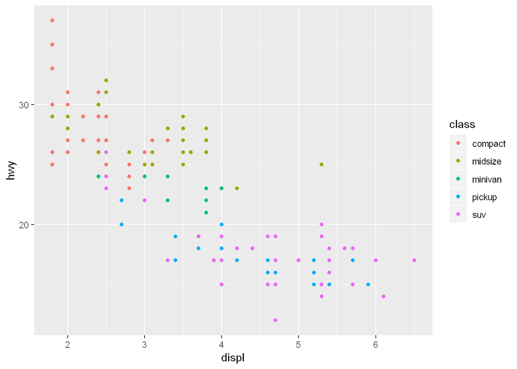

```r
mpg_big <- mpg %>%
  filter(class != "2seater") %>%
  filter(class != "subcompact") %>%
  filter( hwy < 40)

ggplot( data = mpg_big ) +
  geom_point(aes(x = displ, y = hwy, color = class))
```

```r
model2 <- lm(hwy ~ displ, mpg_big)
summary(model2)
```

```
##
## Call:
## lm(formula = hwy ~ displ, data = mpg_big)
##
## Residuals:
##     Min      1Q  Median      3Q     Max
## -6.4175 -1.7755 -0.0011  1.6758  9.1312
##
## Coefficients:
##             Estimate Std. Error t value Pr(>|t|)
## (Intercept)  35.8729     0.6927   51.79   <2e-16 ***
## displ        -3.7744     0.1843  -20.48   <2e-16 ***
## ---
## Signif. codes:  0 '***' 0.001 '**' 0.01 '*' 0.05 '.' 0.1 ' ' 1
##
## Residual standard error: 3.103 on 191 degrees of freedom
## Multiple R-squared:  0.687,  Adjusted R-squared:  0.6854
## F-statistic: 419.3 on 1 and 191 DF,  p-value: < 2.2e-16
```

We can see from the stats (t - values and F stats) that the model has improved (indicating that the relationship is closer to linear.)

## Exercises (2) Aesthetic Mappings (p. 7)

Exercises

## 1. What’s gone wrong with this code? Why are the points not blue?

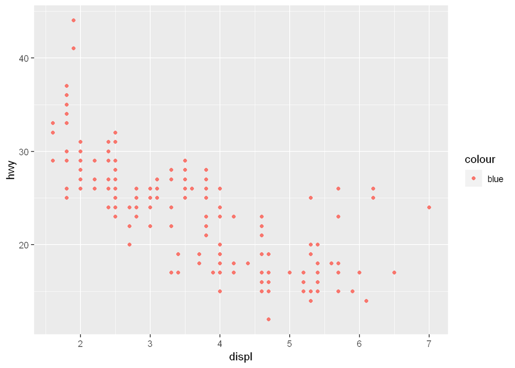

```r
ggplot(data = mpg) +
  geom_point(
    mapping = aes(x = displ, y = hwy, color = "blue")
  )
```

The reason it’s not blue is that in order to assign it a non-variable aesthetic, the assignment has to be made outside of the call to aes (which maps “levels” of an aesthetic to “values” of the data). So what happens is that assigns the default color to a single valued variable “blue”.

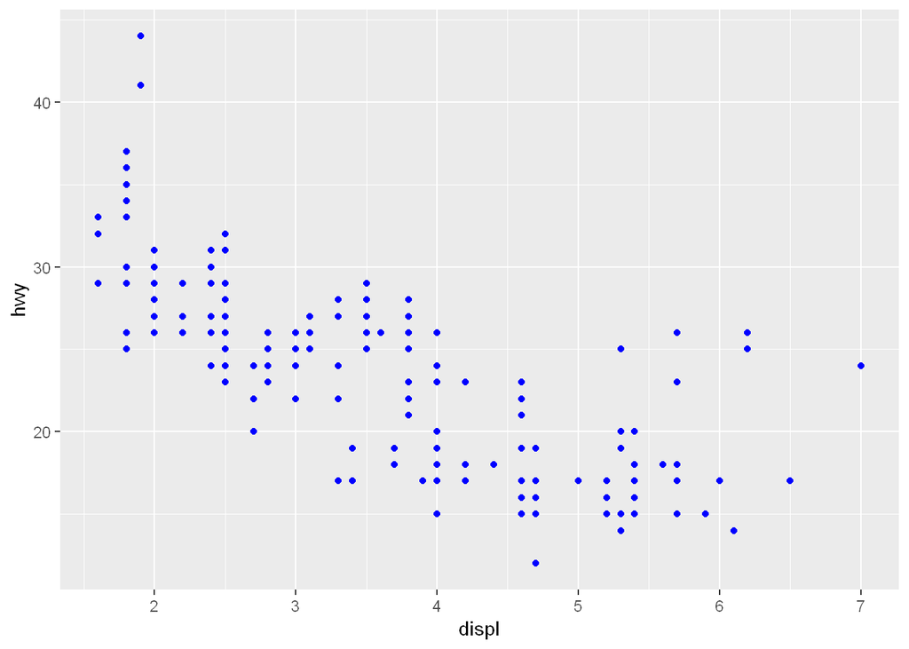

```r
ggplot(data = mpg) +
  geom_point(
    mapping = aes(x = displ, y = hwy), color = "blue"
  )
```

2.Which variables in mpg are categorical? Which variables are continuous? (Hint: type ?mpg to read the documentation) —

```r
?mpg

glimpse(mpg)
```

```
## Observations: 234
## Variables: 11
## $ manufacturer <chr> "audi", "audi", "audi", "audi", "audi", "audi", "...
## $ model        <chr> "a4", "a4", "a4", "a4", "a4", "a4", "a4", "a4 qua...
## $ displ        <dbl> 1.8, 1.8, 2.0, 2.0, 2.8, 2.8, 3.1, 1.8, 1.8, 2.0,...
## $ year         <int> 1999, 1999, 2008, 2008, 1999, 1999, 2008, 1999, 1...
## $ cyl          <int> 4, 4, 4, 4, 6, 6, 6, 4, 4, 4, 4, 6, 6, 6, 6, 6, 6...
## $ trans        <chr> "auto(l5)", "manual(m5)", "manual(m6)", "auto(av)...
## $ drv          <chr> "f", "f", "f", "f", "f", "f", "f", "4", "4", "4",...
## $ cty          <int> 18, 21, 20, 21, 16, 18, 18, 18, 16, 20, 19, 15, 1...
## $ hwy          <int> 29, 29, 31, 30, 26, 26, 27, 26, 25, 28, 27, 25, 2...
## $ fl           <chr> "p", "p", "p", "p", "p", "p", "p", "p", "p", "p",...
## $ class        <chr> "compact", "compact", "compact", "compact", "comp...
```

```r
(mpg_numeric <- dplyr::select_if(mpg, is.numeric))
```

```
## # A tibble: 234 x 5
##    displ  year   cyl   cty   hwy
##    <dbl> <int> <int> <int> <int>
##  1   1.8  1999     4    18    29
##  2   1.8  1999     4    21    29
##  3   2    2008     4    20    31
##  4   2    2008     4    21    30
##  5   2.8  1999     6    16    26
##  6   2.8  1999     6    18    26
##  7   3.1  2008     6    18    27
##  8   1.8  1999     4    18    26
##  9   1.8  1999     4    16    25
## 10   2    2008     4    20    28
## # ... with 224 more rows
```

```r
(mpg_character <- dplyr::select_if(mpg, is.character))
```

```
## # A tibble: 234 x 6
##    manufacturer model      trans      drv   fl    class
##    <chr>        <chr>      <chr>      <chr> <chr> <chr>
##  1 audi         a4         auto(l5)   f     p     compact
##  2 audi         a4         manual(m5) f     p     compact
##  3 audi         a4         manual(m6) f     p     compact
##  4 audi         a4         auto(av)   f     p     compact
##  5 audi         a4         auto(l5)   f     p     compact
##  6 audi         a4         manual(m5) f     p     compact
##  7 audi         a4         auto(av)   f     p     compact
##  8 audi         a4 quattro manual(m5) 4     p     compact
##  9 audi         a4 quattro auto(l5)   4     p     compact
## 10 audi         a4 quattro manual(m6) 4     p     compact
## # ... with 224 more rows
```

```r
categorical <- names(mpg_character)
```

## 3. Map a continuous variable to color, size, and shape. How do these aesthetics behave differently for categorical versus continuous variables?

We will use mtcars which has several continuous variables: disp, hp, wt, mpg, …

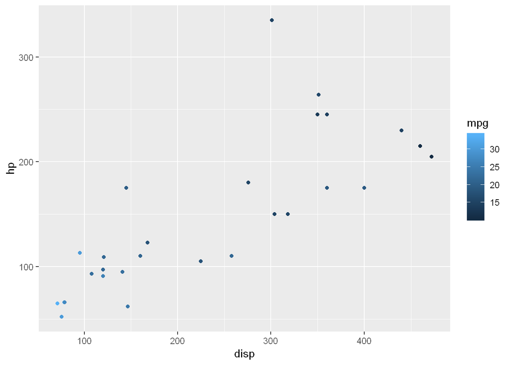

```r
?mtcars

ggplot(data = mtcars) +
  geom_point( aes(x = disp, y = hp, color = mpg))
```

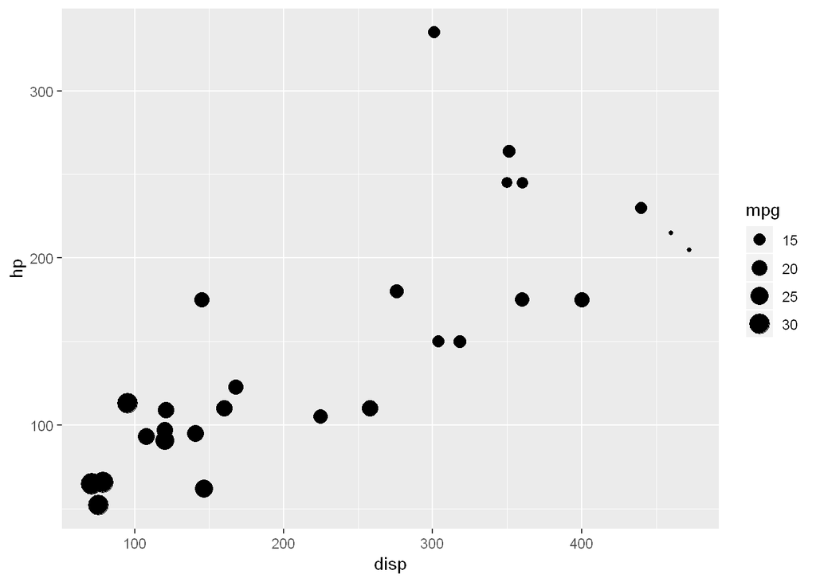

```r
ggplot(data = mtcars) +
  geom_point( aes(x = disp, y = hp, size = mpg))
```

```r
#will cause an error "Error: A continuous variable can not be mapped to shape"
#ggplot(data = mtcars) +
#  geom_point( aes(x = disp, y = hp, shape = mpg))
```

## 4. What happens if you map the same variable to multiple aesthetics?

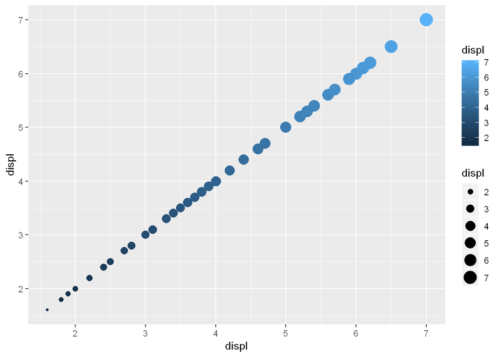

```r
ggplot(data = mpg) +
  geom_point(aes(x = displ, y = displ, color = displ, size = displ))
```

The answer is that it applies all of the aesthetics.

## 5. What does the stroke aesthetic do? What shapes does it work with? (Hint: use ?geom_point)

See the comment (copied from the help, to get the answer) although it seems to actually work with whatever shape!

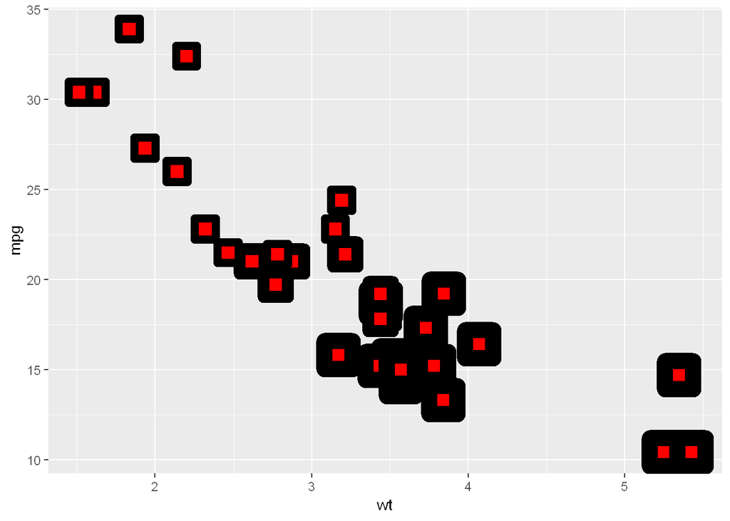

```r
?geom_point
# For shapes that have a border (like 21), you can colour the inside and
# outside separately. Use the stroke aesthetic to modify the width of the
# border
ggplot(mtcars, aes(wt, mpg, stroke = cyl)) +
  geom_point(shape = 22, colour = "black", fill = "red", size = 5)
```

## 6. what happens when you map an aesthetic to something other than a variable name, like aes(color = displ < 5)?

It probably assigns default values as if it were a variable with as many values as the return of whatever you assigned it to. Like assigning color = “blue” inside the aes( )

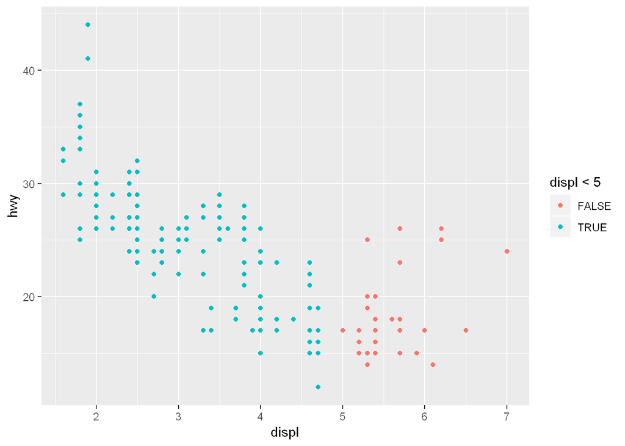

```r
?mpg
ggplot(data = mpg) +
  geom_point(aes(displ, hwy, color = displ < 5))
```

yes, it would appear I guessed correct. It’s good to know what mistakes look like, so that if you get something weird you can debug it faster.

## Exercises (3) Facets (p. 14)

Use facet_wrap to facet by a single variable facet_wrap(~variable, nrow = 2) where ~ variable is actually a formula object Use facet_grid to facet by two varibales facet_grid(row_var ~ col_var)

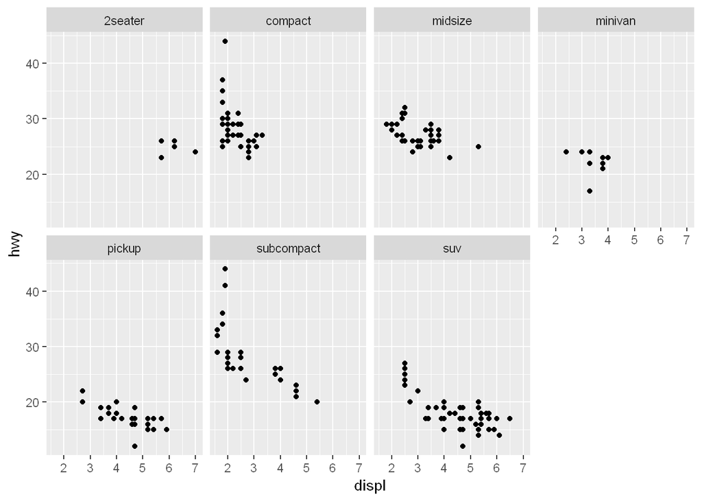

```r
#demo facet_wrap
ggplot(data = mpg) +
  geom_point(mapping = aes(x = displ, y = hwy)) +
  facet_wrap(~ class, nrow = 2)
```

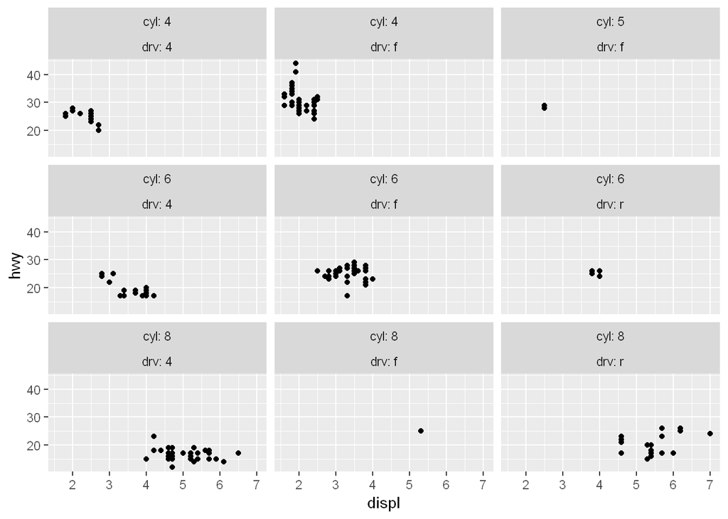

```r
# Use the `labeller` option to control how labels are printed, you can wrap over two variables also:
ggplot(mpg, aes(displ, hwy)) +
  geom_point() +
  facet_wrap(c("cyl", "drv"), labeller = "label_both")
```

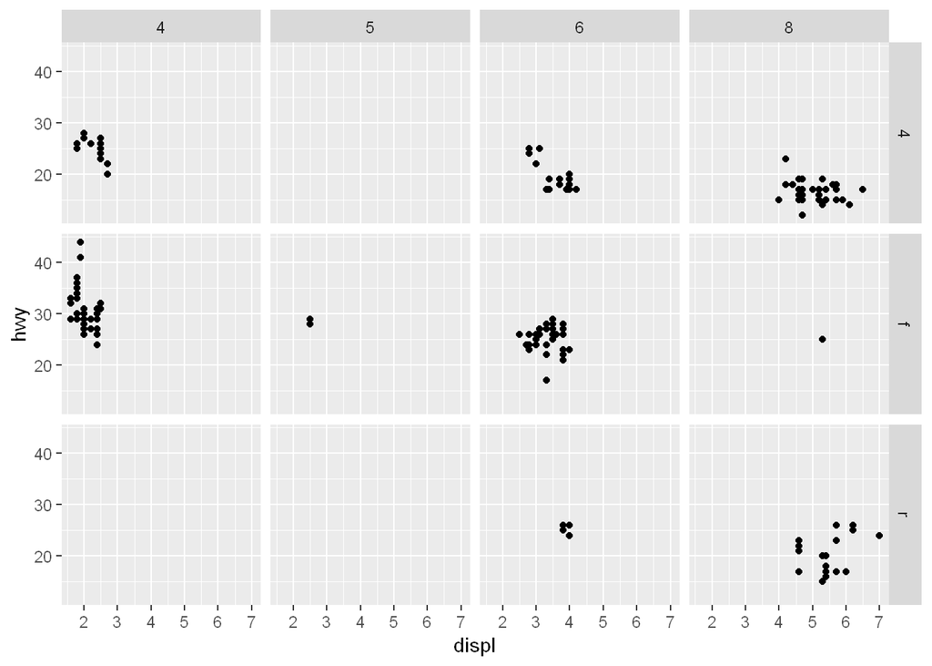

```r
#demo facet_grid
ggplot(data = mpg) +
  geom_point(mapping = aes(x = displ, y = hwy)) +
  facet_grid(drv ~ cyl)
```

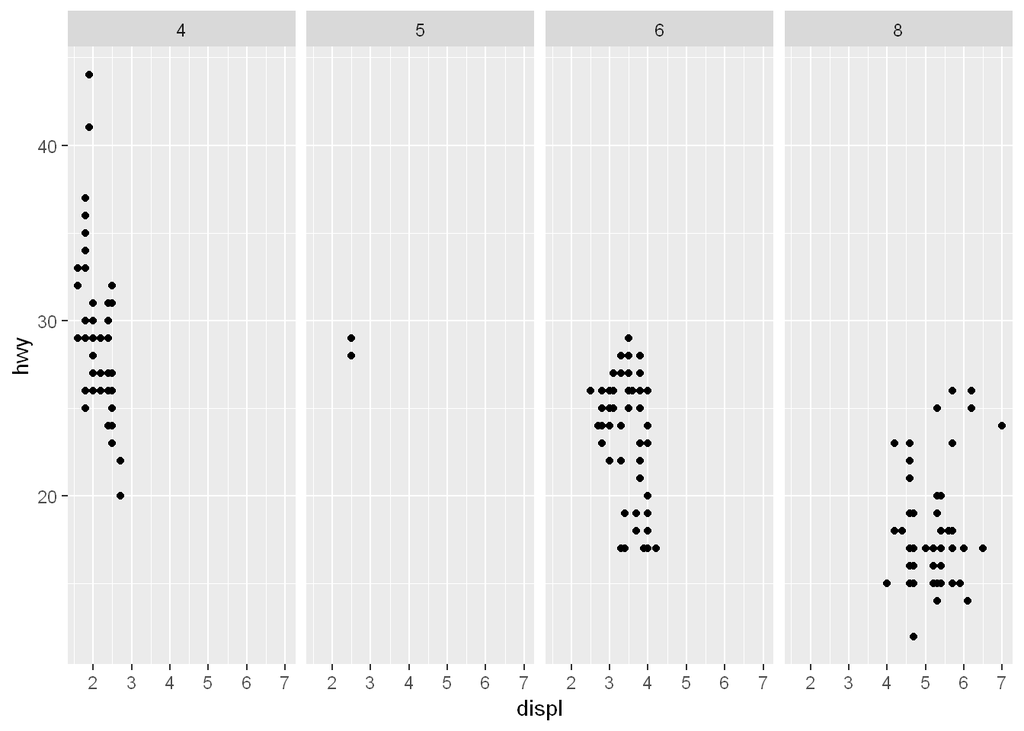

```r
#can replace a variable in facet_grid by .

ggplot(data = mpg) +
  geom_point(mapping = aes(x = displ, y = hwy)) +
  facet_grid(. ~ cyl)
```

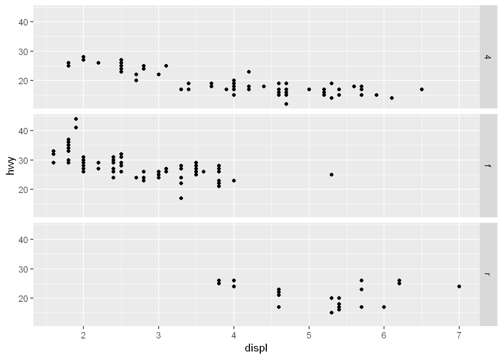

```r
ggplot(data = mpg) +
  geom_point(mapping = aes(x = displ, y = hwy)) +
  facet_grid(drv ~ .)
```

## 1. What happens when you facet on a continuous variable?

Answer: well it cannot be truly continuous.

```r
#orders and obtains the unique values of wt in the mtcars data set
(unique(arrange(mtcars, wt)$wt))
```

```
##  [1] 1.513 1.615 1.835 1.935 2.140 2.200 2.320 2.465 2.620 2.770 2.780
## [12] 2.875 3.150 3.170 3.190 3.215 3.435 3.440 3.460 3.520 3.570 3.730
## [23] 3.780 3.840 3.845 4.070 5.250 5.345 5.424
```

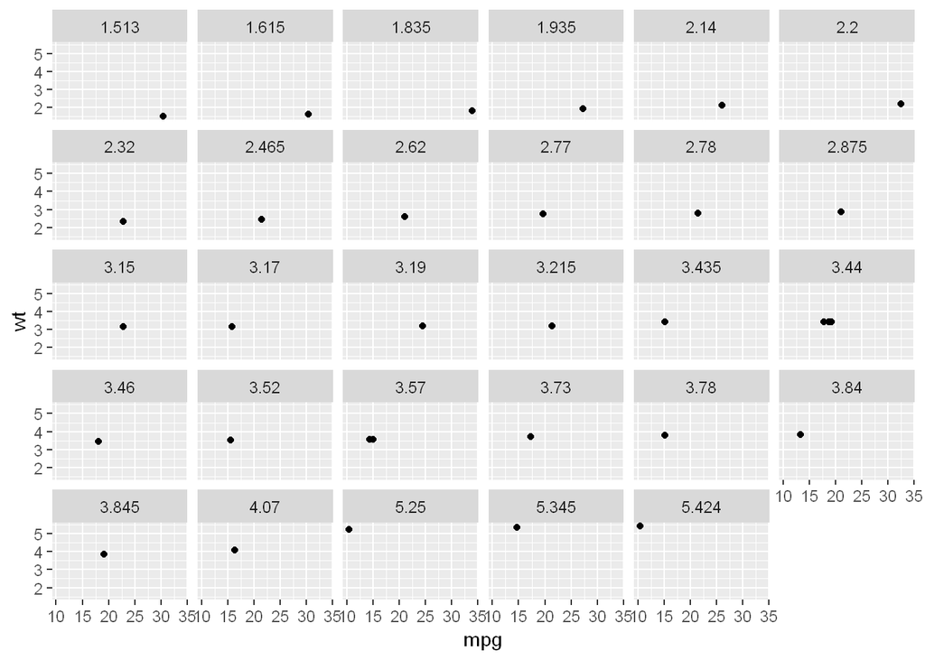

```r
#facets by the 'continuous' value wt
ggplot(data = mtcars) +
  geom_point(aes(mpg, wt)) +
  facet_wrap(~ wt)
```

So what happened is that there is a panel for each unique value in the data frame.

## 2. Wat do the empty cells in a plot with facet_grid(drv ~ cyl) mean? How do tey relate to this plot?

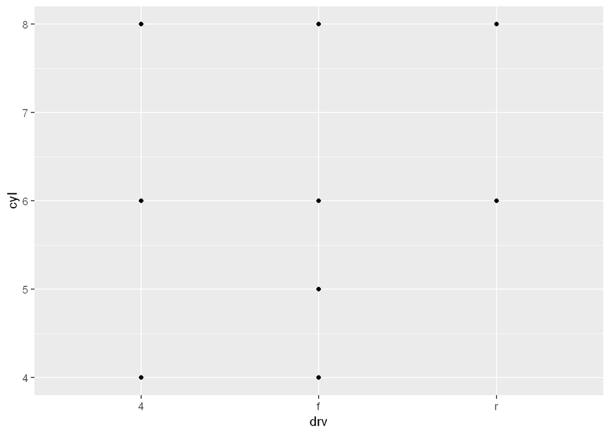

```r
ggplot(data = mpg) +
  geom_point(mapping = aes(x = drv, y = cyl))
```

The facet_grid creates a pane for each combination of (drv,cyl) , so an empty pane represents a combination of those two variable’s values where there is no data that has that combination, similarly to the blank spots on the scatter plot of (drv,cyl), in fact the blank panels are in the same place but upside down.

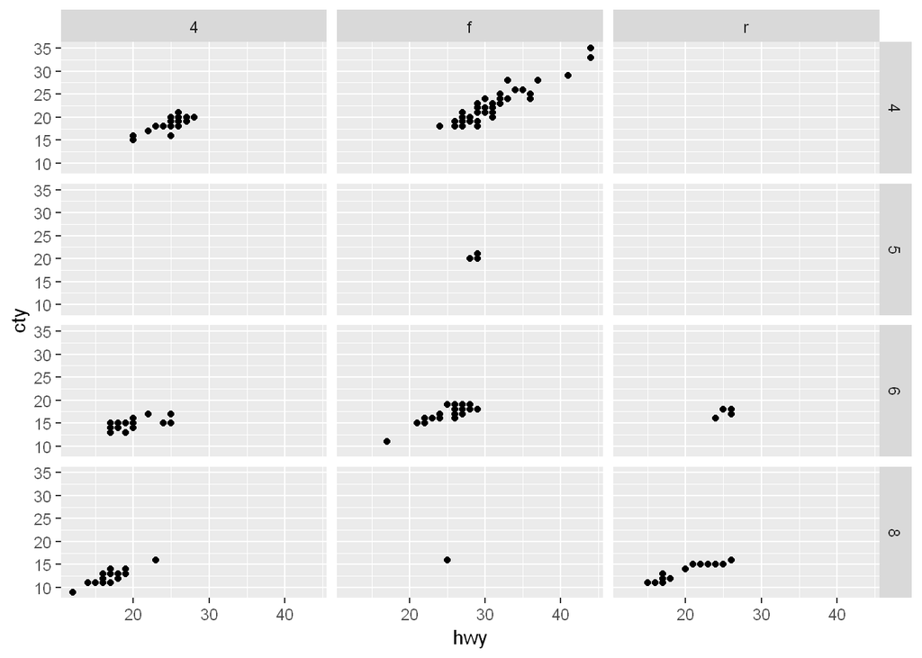

```r
ggplot(data = mpg) +
  geom_point(mapping = aes(x = hwy, y = cty)) +
  facet_grid(cyl ~ drv)
```

## 3. What plots does the following code make? What does . do?

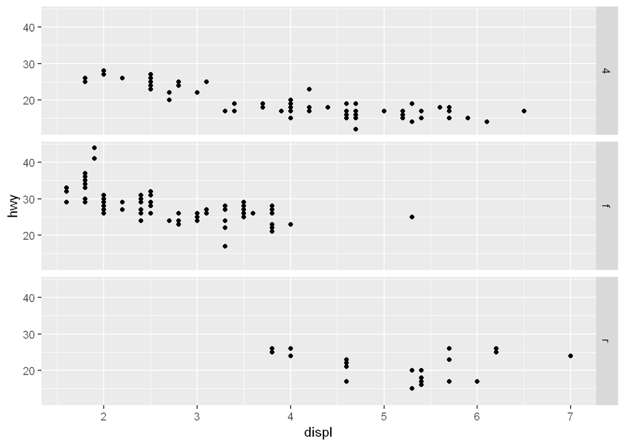

```r
ggplot(data = mpg) +
  geom_point(mapping = aes(x = displ, y = hwy)) +
  facet_grid(drv ~ .)
```

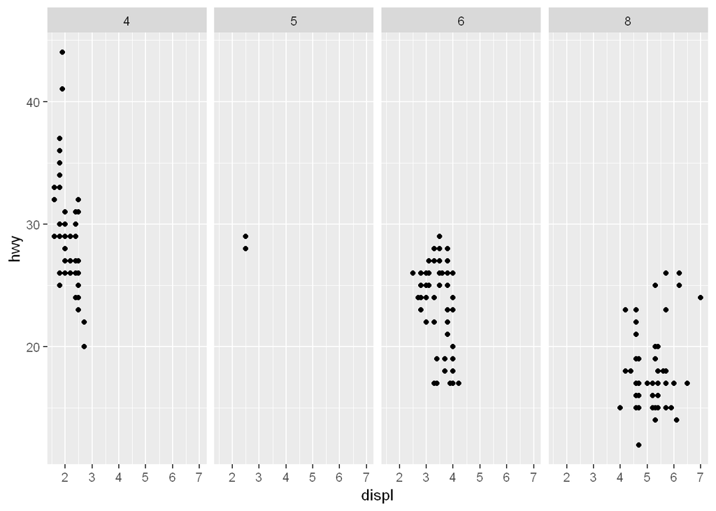

```r
ggplot(data = mpg) +
  geom_point(mapping = aes(x = displ, y = hwy)) +
  facet_grid(. ~ cyl)
```

The dot in the second slot means that the graphs are not faceted along x, but that the y dimension is still faceted along a variable. Since the whole graph is of fixed size it gives horizontal strips. The opposite situation is true when the dot is in the other side of ~ where it indicates to not facet in the y direction, giving vertical strips.

## 4. What are the advantages to using faceting instead of the color aesthetic? What are the disadvantages? How might the balance change if you had a larger data set?

Adv: allows you to see the relationship of two patterns characterized by different combinations of categorical variables easier, and this benefit increases with larger data sets where the data would overlap even more if merely colored. Often colored data appears interwoven and it’s hard to visually separate the individual color groups. However it makes it harder to compare the groups (by group I mean the data relationship for a fixed combination of categorical variables) with eachother when you facet, where as with color it’s often easy to say “this data is always below that data”.

5. Read ?facet_wrap. What does nrow do? What does ncol do? What other options control the layout of the individual panels? Why doesn’t facet_grid() have nrow and ncol variables?

```r
?facet_wrap
#facet_wrap wraps a 1d sequence of panels into 2d. This is generally a better use of screen space than facet_grid() because most displays are roughly rectangular.
?facet_gride
```

```
## No documentation for 'facet_gride' in specified packages and libraries:
## you could try '??facet_gride'
```

```r
#facet_grid() forms a matrix of panels defined by row and column faceting variables. It is most useful when you have two discrete variables, and all combinations of the variables exist in the data.
```

Facet_wrap is a 1 dimensional strip of plots based on the value of 1 categorical variable, or a sequence of ordered pairs of a combination of multiple variables. You then control how that Strip is arranged into a grid by settin nrow and ncol. Facet_grid does not have this option because it varies on two variables and therefore must always be a grid, and nrow and ncol are not arbitrary but defined by the faceting variables.

## SUPER COOL FEATURE OF FACETING

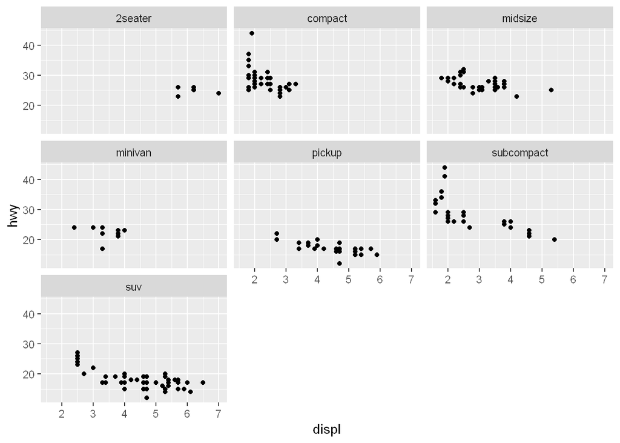

```r
#normal faceting
ggplot(mpg, aes(displ, hwy)) +
  geom_point() +
  facet_wrap(~class)
```

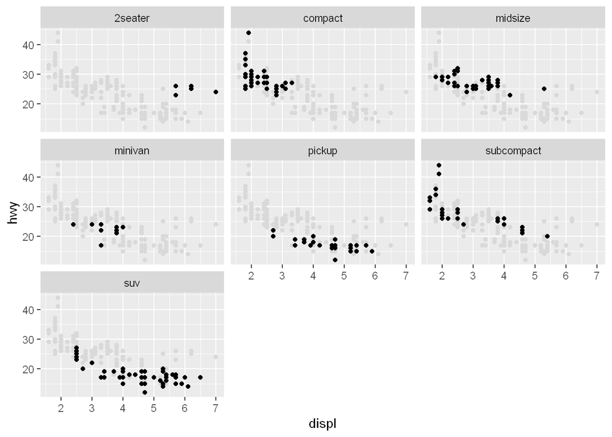

```r
# To repeat the same data in every panel, simply construct a data frame
# that does not contain the faceting variable.
ggplot(mpg, aes(displ, hwy)) +
  #first add a geometry layer where the data is mpg without the class column, this causes it to copy across facets because you are faceting across a variable that isn't used.
  geom_point(data = transform(mpg, class = NULL), color = "grey85") +
  geom_point(color = 'black') +
  facet_wrap(~class)
```

```r
?transform
```

## Geometric Objects

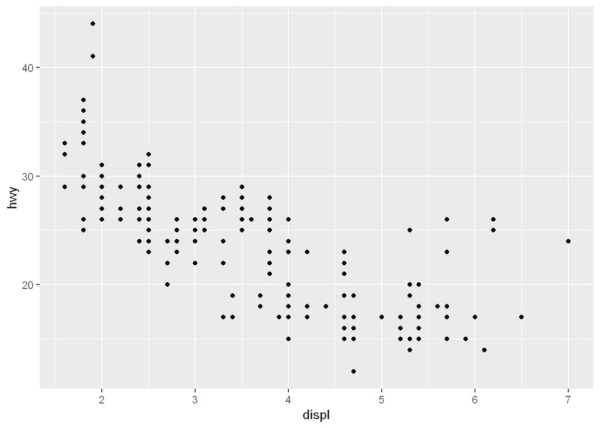

```r
p <- ggplot(data = mpg)

p + geom_point(mapping = aes(x = displ, y = hwy))
```

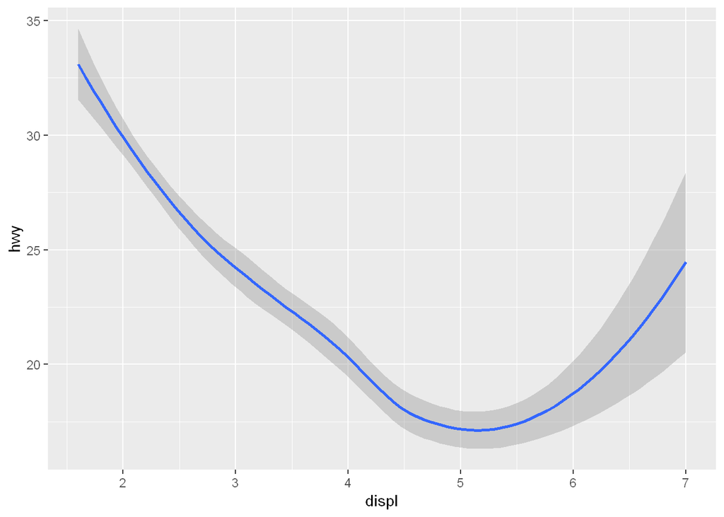

```r
p + geom_smooth(mapping = aes(x = displ, y = hwy))
```

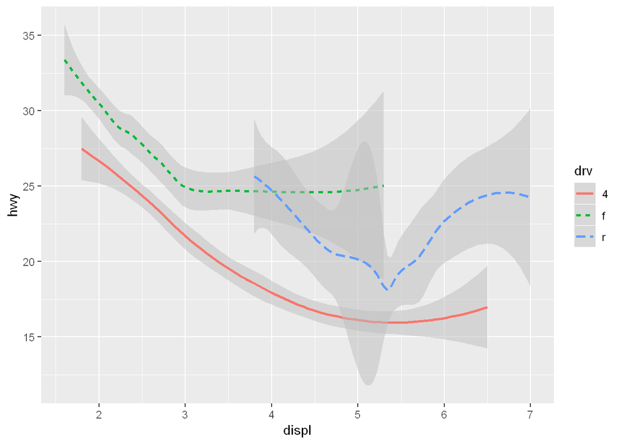

```r
q <- p + geom_smooth(mapping = aes(x = displ, y = hwy, linetype = drv, color = drv), fill = 'grey', alpha = 0.5)
q
```

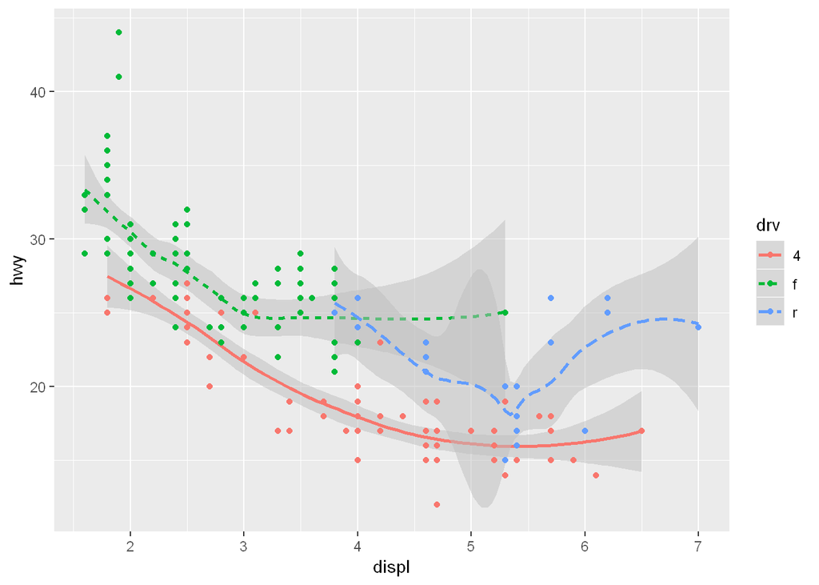

```r
q + geom_point(mapping = aes(x = displ, y = hwy, color = drv))
```

```r
?geom_smooth
```

## Exercises (4) Geometric Objects

## 1. What geom would you use to draw a line cart? A boxplot? A histogram? An area chart?

for a line chart - geom_line() for a box plot - geom_boxplot() for a histogram - geom_histogram() #note this is much different than geom_col() or geom_bar() for an area chart - geom_area()

## 2.Run this code in your head and predict what the output will look like. Then, run the R and check your predictions.

ggplot( data = mpg, mapping = aes(x = displ, y = hwy, color = drv) ) + geom_point() + geom_smooth(se = FALSE)

My guess, it’s going to look exactly like the graph directly above but without the standard error shading.

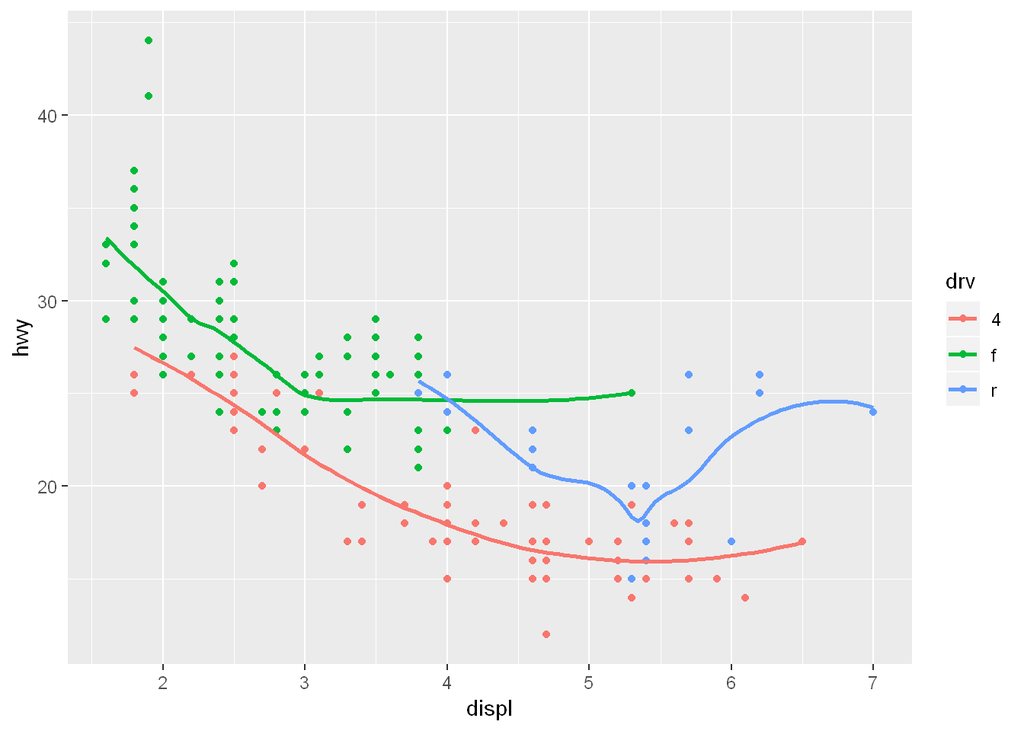

```r
ggplot(
  data = mpg,
  mapping = aes(x = displ, y = hwy, color = drv)
) +
geom_point() +
geom_smooth(se = FALSE)
```

Almost nailed it, except I forgot that linetype was actually also linked to drv in the above graph.